# Citizenship, Race and Level of Education

## Introduction

I am interested in how race and the level of education affects the income of people that have gained US citizenship through the process of naturalization. The variables I have selected to investigate this interdependency are age, income, race, employment status, level of education, year of entry, and period of citizenship. I calculated the period of citizenship as the difference between the year of entry and the year when the person acquired the citizenship.

## Data

The variables I selected to answer my research question are as follows: 1. **Age** (continuous variable) 2. **Income** (continuous variable) 3. **Race** (categorical variable) 4. **Employment status** (categorical variable) 5. **Level of education** (categorical variable) 6. **Year of entry** (continuous variable) 7. **Period of citizenship** (continuous variable)

These variables are retrieved from the 2018 ACS1 dataset for California. The following table presents the sample mean, median, standard deviation, interquartile range, and population mean for the continuous variables, with a 95% confidence interval. The distribution for each of the continuous variables is visualized on Figure 1, 2 and 3.

```r
summary_table <- tibble(Statistic = c("Sample mean",
                "Median",
                "Standard deviation",
                "Interquartile range",
                "Population mean (95% confidence)"),
  `Median age (years)` = c(prettyNum(age_summary["Mean"], digits=3),
                           age_summary["Median"],
                           prettyNum(age_sd, digits = 3),
                           paste(age_summary["1st Qu."],"to",
                                 age_summary["3rd Qu."]),
                           paste(prettyNum(age_pop_mean_int$conf.int[1],
                                           digits=3), "to",
                                 prettyNum(age_pop_mean_int$conf.int[2],
                                               digits=3))),
    `Income` = c(prettyNum(income_summary["Mean"], digits=3),
                           income_summary["Median"],
                           prettyNum(income_sd, digits = 3),
                           paste(income_summary["1st Qu."],"to",
                                 income_summary["3rd Qu."]),
                           paste(prettyNum(income_pop_mean_int$conf.int[1],
                                           digits=3), "to",
                                 prettyNum(income_pop_mean_int$conf.int[2],
                                               digits=3))),
    `Period of citizenship (years)` = c(prettyNum(periodcit_summary["Mean"], digits=3),
                           periodcit_summary["Median"],
                           prettyNum(income_sd, digits = 3),
                           paste(periodcit_summary["1st Qu."],"to",
                                 periodcit_summary["3rd Qu."]),
                           paste(prettyNum(periodcit_pop_mean_int$conf.int[1],
                                           digits=3), "to",
                                 prettyNum(periodcit_pop_mean_int$conf.int[2],
                                               digits=3))))
knitr::kable(summary_table,
             caption = "Table 1: Summary for Continuous Variables")
```

Table 1: Summary for Continuous Variables

[output not shown]

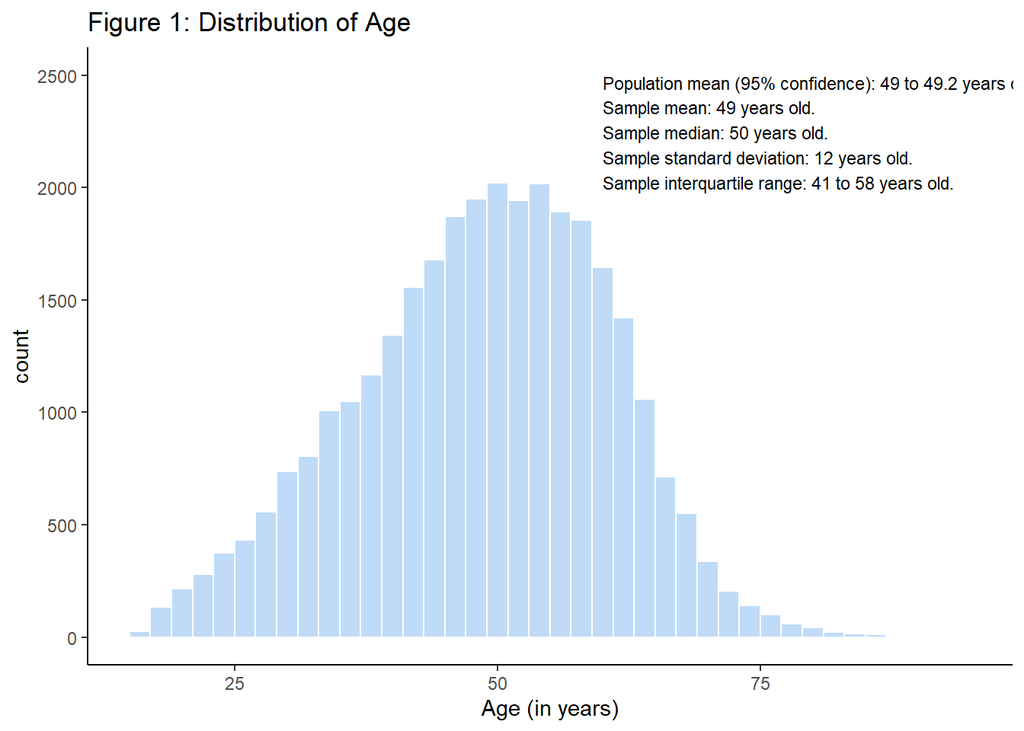

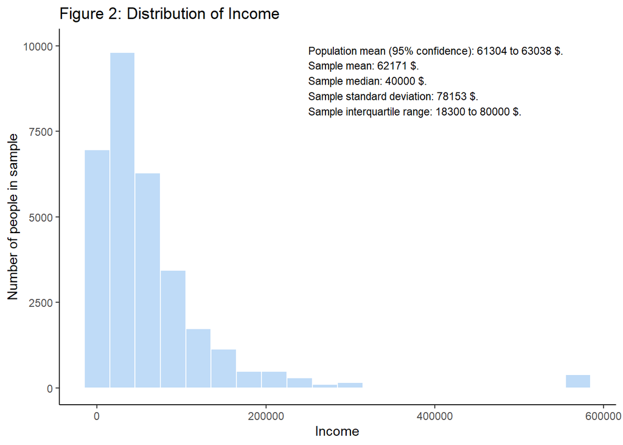

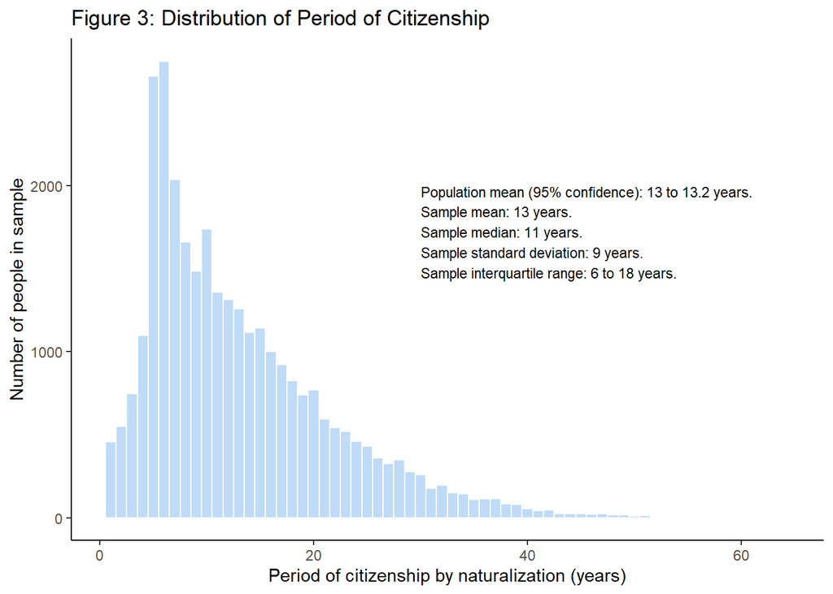

In the following tables, I observe the shares of the categorical variables, namely race, employment, and level of education.

```r
employment <- unique(ESR_label)
employment
```

```
## [1] "Employed"    "1Unemployed"
```

```r
employed <- t.test(ESR_label == employment [1])
unemployed <- t.test(ESR_label == employment [2])
shares_employment <- tibble(Employment = c("Employed",
                            "Unemployed"),
                 `Share` = c(employed$estimate,
                             unemployed$estimate),
                 Low = c(employed$conf.int[1],
                         unemployed$conf.int[1]),
                 High = employed$conf.int[2],
                         unemployed$conf.int[2])
knitr::kable(shares_employment,
             caption = "Table 2: Employment shares")
```

Table 2: Employment shares

| Employment | Share | Low | High | unemployed$conf.int[2] |
| --- | --- | --- | --- | --- |
| Employed | 0.9635793 | 0.9615021 | 0.9656566 | 0.0384979 |
| Unemployed | 0.0364207 | 0.0343434 | 0.9656566 | 0.0384979 |

Employed people make up 96% of the dataset.

```r
highsch <- t.test(SCHL_label == education [1])
bachelors <- t.test(SCHL_label == education [2])
nosch <- t.test(SCHL_label == education [3])

shares_education <- tibble(Education = c("HS Graduate or Lower",
                            "Bachelor's degree or Higher",
                            "No Schooling Completed"),
                 `Share` = c(highsch$estimate,
                             bachelors$estimate,
                             nosch$estimate),
                 Low = c(highsch$conf.int[1],
                         bachelors$conf.int[1],
                         nosch $conf.int[1]),
                 High = highsch$conf.int[2],
                         bachelors$conf.int[2],
                         nosch $conf.int[2])
knitr::kable(shares_education,
             caption = "Table 3: Level of education shares")
```

Table 3: Level of education shares

| Education | Share | Low | High | bachelors$conf.int[2]\| nosch$conf.int[2] |  |
| --- | --- | --- | --- | --- | --- |
| HS Graduate or Lower | 0.5434616 | 0.5379383 | 0.5489849 | 0.425687 | 0.0383993 |
| Bachelor’s degree or Higher | 0.4202138 | 0.4147406 | 0.5489849 | 0.425687 | 0.0383993 |
| No Schooling Completed | 0.0363246 | 0.0342500 | 0.5489849 | 0.425687 | 0.0383993 |

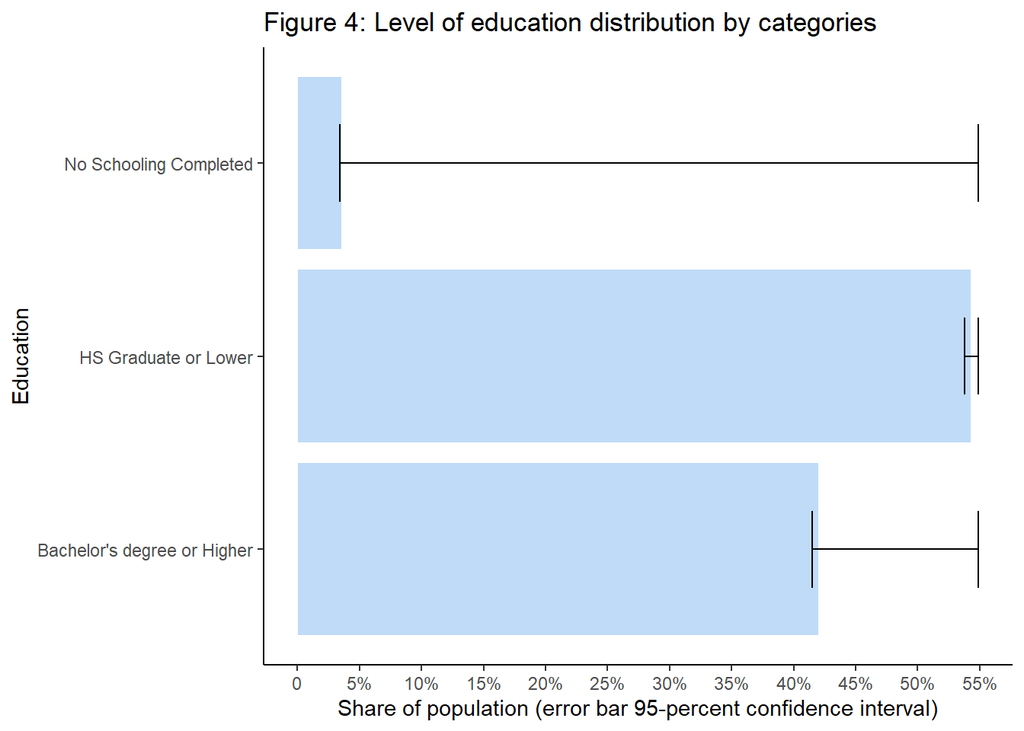

```r
white <- t.test(RACE == race [1])
asian <- t.test(RACE == race [2])
black <- t.test(RACE == race [3])
other <- t.test(RACE == race [4])
aian <- t.test(RACE == race [5])

shares_race <- tibble(Race = c("White",
                            "Asian",
                            "Black",
                            "Other",
                            "America Indian and Alaska Native"),
                 `Share` = c(white$estimate,
                             asian$estimate,
                             black$estimate,
                             other$estimate,
                             aian$estimate),
                 Low = c(white$conf.int[1],
                         asian$conf.int[1],
                         black$conf.int[1],
                         other$conf.int[1],
                         aian$conf.int[1]),
                 High = c(white$conf.int[2],
                         asian$conf.int[2],
                         black$conf.int[2],
                         other$conf.int[2],
                         aian$conf.int[2]))
knitr::kable(shares_race,
             caption = "Table 4: Race categories distribution")
```

Table 4: Race categories distribution

| Race | Share | Low | High |
| --- | --- | --- | --- |
| White | 0.3577418 | 0.3524267 | 0.3630569 |
| Asian | 0.4744607 | 0.4689237 | 0.4799978 |
| Black | 0.0194585 | 0.0179268 | 0.0209902 |
| Other | 0.1405940 | 0.1367396 | 0.1444484 |
| America Indian and Alaska Native | 0.0077450 | 0.0067729 | 0.0087171 |

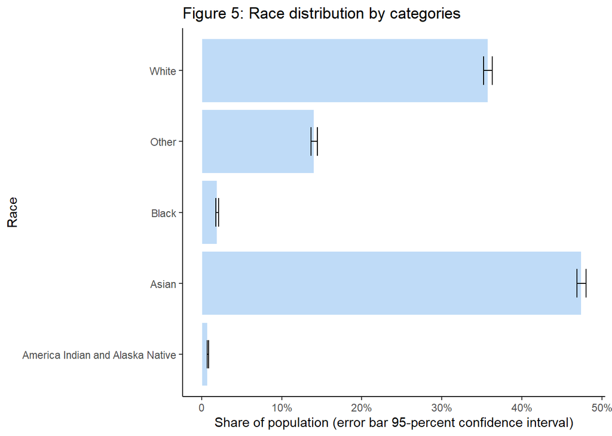

## Methods

I will initially run correlation tests between 2 variables to test the waters. In addition, I will take into account the statistical significance of the models, and do descriptive analysis of two variables.

### Descriptive analysis of the continuous and categorical variables

```r
correlation_age_income <- cor.test(citizenship_data$AGEP, citizenship_data$WAGP)
correlation_age_income
```

```
##
##  Pearson's product-moment correlation
##
## data:  citizenship_data$AGEP and citizenship_data$WAGP
## t = 0.34845, df = 31244, p-value = 0.7275
## alternative hypothesis: true correlation is not equal to 0
## 95 percent confidence interval:
##  -0.009116921  0.013059029
## sample estimates:
##         cor
## 0.001971297
```

The p-value for the correlation test of age and income is 0.727, meaning that this relationship has no statistical significance. Figure 6 is a scatterplot of age and income.

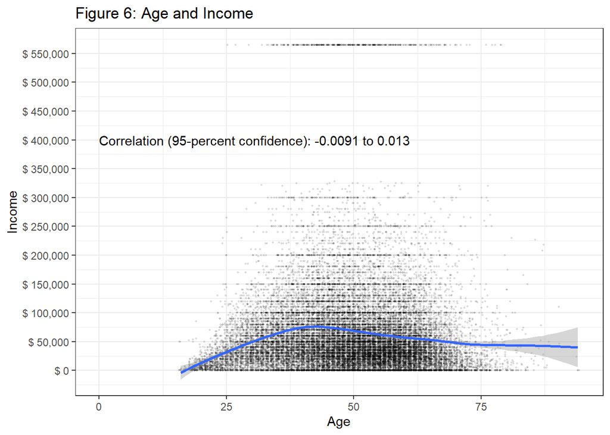

```r
correlation_age_periodnat <- cor.test(citizenship_data$years_to_nat, citizenship_data$AGEP)
correlation_age_periodnat
```

```
##
##  Pearson's product-moment correlation
##
## data:  citizenship_data$years_to_nat and citizenship_data$AGEP
## t = 28.823, df = 31244, p-value < 0.00000000000000022
## alternative hypothesis: true correlation is not equal to 0
## 95 percent confidence interval:
##  0.1501156 0.1717173
## sample estimates:
##       cor
## 0.1609357
```

The correlation test for period of citizenship and age has a p-value equal to 2.2e-16, meaning there is a statistically significant relationship between the variables.

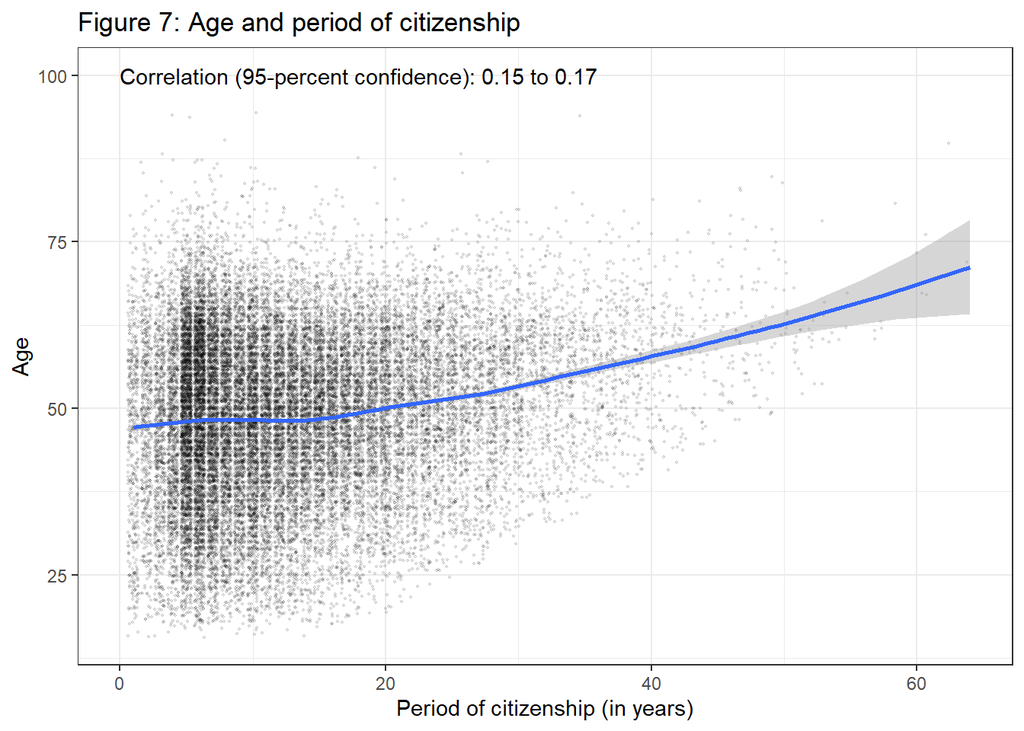

```r
correlation_income_period_nat <- cor.test(citizenship_data$years_to_nat, citizenship_data$WAGP)
correlation_income_period_nat
```

```
##
##  Pearson's product-moment correlation
##
## data:  citizenship_data$years_to_nat and citizenship_data$WAGP
## t = -11.438, df = 31244, p-value < 0.00000000000000022
## alternative hypothesis: true correlation is not equal to 0
## 95 percent confidence interval:
##  -0.07561043 -0.05352686
## sample estimates:
##         cor
## -0.06457655
```

The p-value for income and period of citizenship is 2.2e-16, meaning there is a statistically significant relationship between period of citizenship and income.

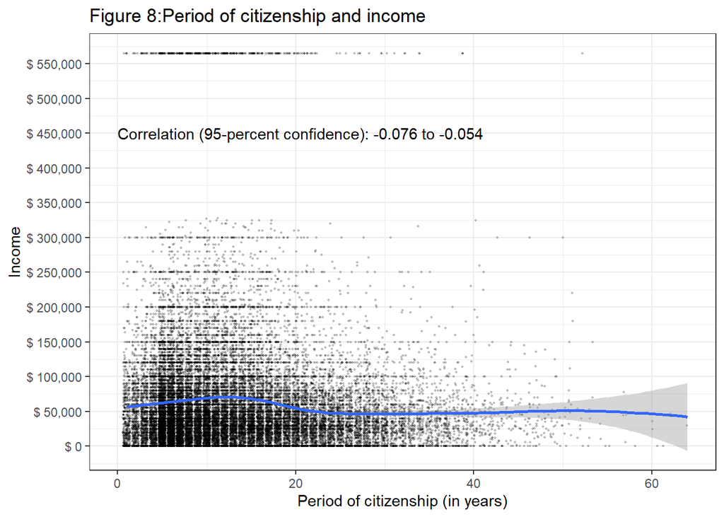

```r
anova_race_income <- aov(WAGP ~ RACE, data = citizenship_data)

summary(anova_race_income)
```

```
##                Df          Sum Sq       Mean Sq F value              Pr(>F)
## RACE            4   4002572154189 1000643038547   167.3 <0.0000000000000002 ***
## Residuals   31241 186836437241977    5980488372
## ---
## Signif. codes:  0 '***' 0.001 '**' 0.01 '*' 0.05 '.' 0.1 ' ' 1
```

I ran an Anova test on Race and Income. Since the p-value is 2e-16, there is a statistically significant relationship between race and income. For a more in-depth look, I will run a Tukey’s Honestly Significant (THS) test.

```r
differences <- TukeyHSD(anova_race_income)

as_tibble(cbind(pair = row.names(differences$RACE),
                differences$RACE))
```

```
## # A tibble: 10 x 5
##    pair        diff           lwr            upr            `p adj`
##    <chr>       <chr>          <chr>          <chr>          <chr>
##  1 AIAN-1White -17041.989452~ -30748.284864~ -3335.6940400~ 0.00625012138291114
##  2 Asian-1Whi~ 11878.7594444~ 9236.29534341~ 14521.2235455~ 0
##  3 Black-1Whi~ -1537.7215642~ -10322.405643~ 7246.96251516~ 0.98940247994523
##  4 Other-1Whi~ -21481.282083~ -25237.686735~ -17724.877431~ 0
##  5 Asian-AIAN  28920.7488969~ 15250.2258388~ 42591.2719549~ 0.00000007876595564~
##  6 Black-AIAN  15504.2678882~ -529.17399212~ 31537.7097685~ 0.0637141584833867
##  7 Other-AIAN  -4439.2926312~ -18368.081525~ 9489.49626316~ 0.908149040461236
##  8 Black-Asian -13416.481008~ -22145.246163~ -4687.7158540~ 0.00026666665523789
##  9 Other-Asian -33360.041528~ -36983.747181~ -29736.335875~ 0
## 10 Other-Black -19943.560519~ -29071.501169~ -10815.619869~ 0.00000002520832254~
```

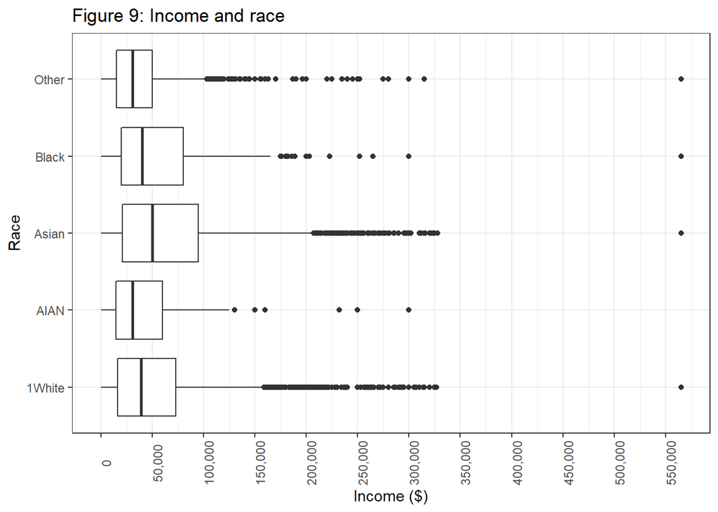

```r
anova_race_period_nat <- aov(years_to_nat ~ RACE, data = citizenship_data)

summary(anova_race_period_nat)
```

```
##                Df  Sum Sq Mean Sq F value              Pr(>F)
## RACE            4  242659   60665   890.9 <0.0000000000000002 ***
## Residuals   31241 2127235      68
## ---
## Signif. codes:  0 '***' 0.001 '**' 0.01 '*' 0.05 '.' 0.1 ' ' 1
```

There is a statistically significant relationship between race and period of citizenship, given the p-value of 2e-16. I will run the THS test.

```r
differences <- TukeyHSD(anova_race_period_nat)

as_tibble(cbind(pair = row.names(differences$RACE),
                differences$RACE))
```

```
## # A tibble: 10 x 5
##    pair       diff           lwr            upr           `p adj`
##    <chr>      <chr>          <chr>          <chr>         <chr>
##  1 AIAN-1Whi~ 1.00052346033~ -0.4619803025~ 2.4630272232~ 0.335766636820291
##  2 Asian-1Wh~ -4.7239220680~ -5.0058810930~ -4.441963043~ 0
##  3 Black-1Wh~ -3.2719863265~ -4.2093390637~ -2.334633589~ 0.0000000000000415223~
##  4 Other-1Wh~ 2.39449264121~ 1.99367274254~ 2.7953125398~ 0
##  5 Asian-AIAN -5.7244455284~ -7.1831322713~ -4.265758785~ 0.0000000000000458522~
##  6 Black-AIAN -4.2725097868~ -5.9833272161~ -2.561692357~ 0.0000000000961317692~
##  7 Other-AIAN 1.39396918087~ -0.0922753190~ 2.8802136807~ 0.0782452253637566
##  8 Black-Asi~ 1.45193574154~ 0.52054972512~ 2.3833217579~ 0.000205280354355075
##  9 Other-Asi~ 7.11841470928~ 6.73175420082~ 7.5050752177~ 0
## 10 Other-Bla~ 5.66647896773~ 4.69249970154~ 6.6404582339~ 0
```

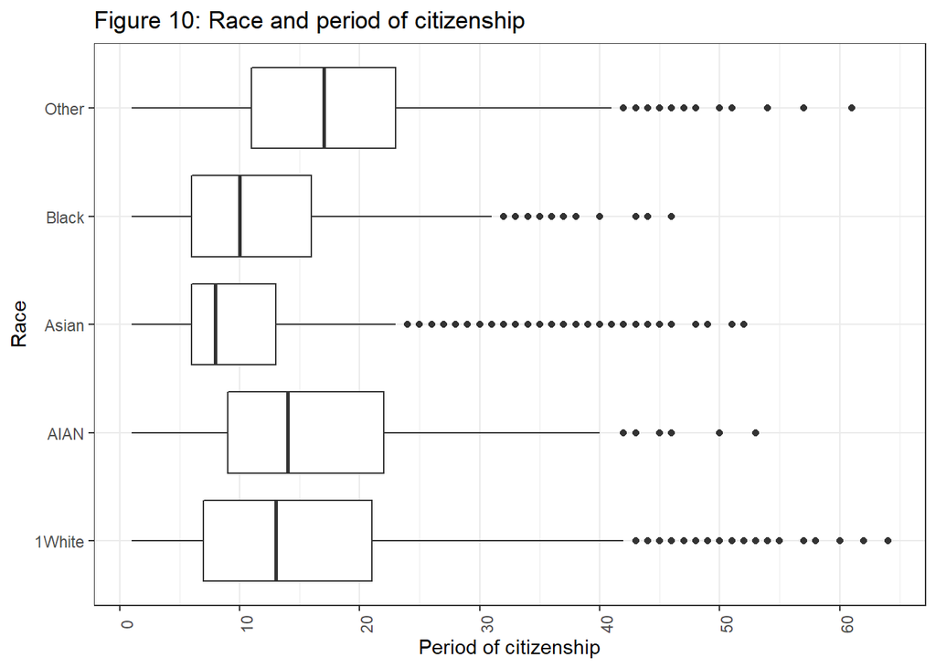

```r
anova_edu_income <- aov(WAGP ~ SCHL_label, data = citizenship_data)

summary(anova_edu_income)
```

```
##                Df          Sum Sq        Mean Sq F value              Pr(>F)
## SCHL_label      2  24545383652593 12272691826297    2306 <0.0000000000000002
## Residuals   31243 166293625743571     5322588284
##
## SCHL_label  ***
## Residuals
## ---
## Signif. codes:  0 '***' 0.001 '**' 0.01 '*' 0.05 '.' 0.1 ' ' 1
```

Since there is a statistical significance, owed to a low p-value of 2e-16, I will run a THS test.

```r
differences <- TukeyHSD(anova_edu_income)

as_tibble(cbind(pair = row.names(differences$SCHL_label),
                differences$SCHL_label))
```

```
## # A tibble: 3 x 5
##   pair                         diff        lwr         upr         `p adj`
##   <chr>                        <chr>       <chr>       <chr>       <chr>
## 1 Bachelor's degree or Higher~ 56025.0212~ 54037.9558~ 58012.0866~ 0
## 2 No Schooling Completed-1HS ~ -10094.965~ -15337.184~ -4852.7462~ 0.0000190207~
## 3 No Schooling Completed-Bach~ -66119.986~ -71410.150~ -60829.822~ 0
```

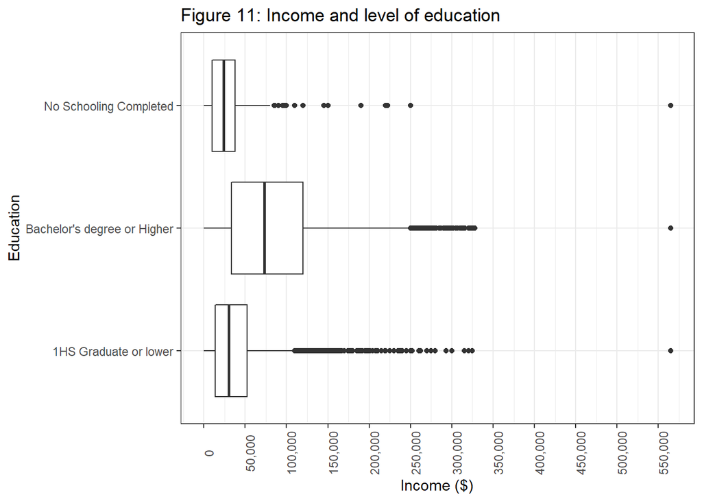

```r
chi_sq_race_work <- chisq.test(citizenship_data$RACE, citizenship_data$ESR_label)
chi_sq_race_work
```

```
##
##  Pearson's Chi-squared test
##
## data:  citizenship_data$RACE and citizenship_data$ESR_label
## X-squared = 18.365, df = 4, p-value = 0.001047
```

After running the Pearson’s Chi-squared test, the p-value of 0.001 indicates that there is a statistically significant relationship between race and employment status.

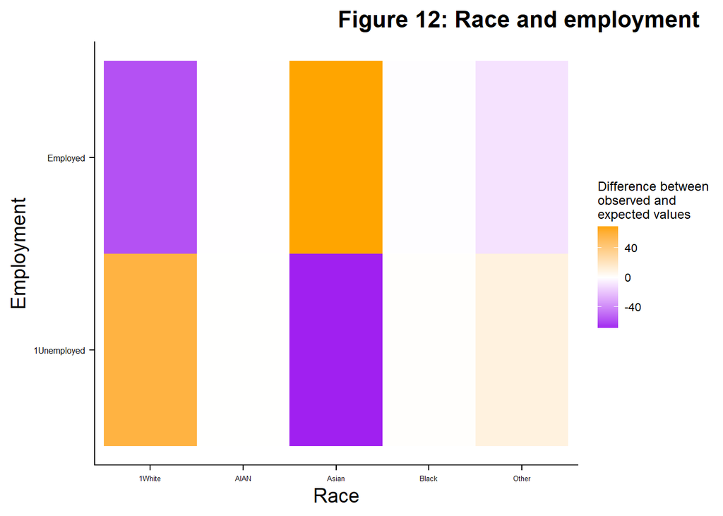

```r
chi_sq_race_edu <- chisq.test(citizenship_data$RACE, citizenship_data$SCHL_label)
chi_sq_race_edu
```

```
##
##  Pearson's Chi-squared test
##
## data:  citizenship_data$RACE and citizenship_data$SCHL_label
## X-squared = 3121.5, df = 8, p-value < 0.00000000000000022
```

The p-value of 2.2e-16 of the Pearson’s Chi-squared test indicates tat there is a statistically significant relationship between level of education and race.

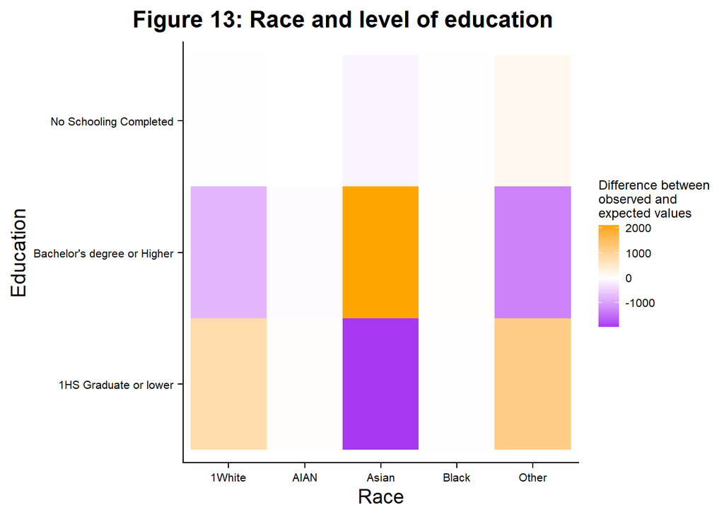

### Regression models

I will run regression models, choosing the following variables: 1. Dependent: Income. 2. Independent: Race, employment, level of education and period of citizenship.

The preferred regression model has an interaction term for education, as opposed to the interaction term of employment for the initial model.

```r
coeff_names <- c("Race American Indian \n Alaska Native \n(Compared to White)" = "RACEAIAN",
                 "Race Asian \n(Compared to White)" = "RACEAsian",
                 "Race Black \n(Compared to White)" = "RACEBlack",
                 "Race Other \n(Compared to White)" = "RACEOther",
                 "Employed \n(Compared to unemployed)" = "ESR_labelEmployed",
                 "Education \nBachelor's degree or Higher \n(Compared to high school degree)" = "SCHL_labelBachelor's degree or Higher",
                 "Education \nNo Schooling Completed \n(Compared to high school degree)" = "SCHL_labelNo Schooling Completed",
                 "Period of naturalization" = "years_to_nat",
                 "Interaction \nPeriod of naturalization and \nBachelor's degree or Higher" = "SCHL_labelBachelor's degree or Higher:years_to_nat",
                 "Interaction \nPeriod of naturalization and \nNo Schooling Completed" = "SCHL_labelNo Schooling Completed:years_to_nat",
                 "Interaction \nEmployed and \nBachelor's degree or Higher" = "ESR_labelEmployed:SCHL_labelBachelor's degree or Higher",
                 "Interaction \nEmployed and \nNo Schooling Completed" = "ESR_labelEmployed:SCHL_labelNo Schooling Completed",
                 "Interaction \nAmerican Indian \n Alaska Native \nand Bachelor's degree or Higher" = "RACEAIAN:SCHL_labelBachelor's degree or Higher",
                 "Interaction \nAsian \nand Bachelor's degree or Higher" = "RACEAsian:SCHL_labelBachelor's degree or Higher",
                 "Interaction \nBlack \nand Bachelor's degree or Higher" = "RACEBlack:SCHL_labelBachelor's degree or Higher",
                 "Interaction \nOther \nand Bachelor's degree or Higher" = "RACEOther:SCHL_labelBachelor's degree or Higher",
                 "Interaction \nAmerican Indian \n Alaska Native \nand No Schooling Completed" = "RACEAIAN:SCHL_labelNo Schooling Completed",
                 "Interaction \nAsian \nand No Schooling Completed" = "RACEAsian:SCHL_labelNo Schooling Completed",
                 "Interaction \nBlack \nand No Schooling Completed" = "RACEBlack:SCHL_labelNo Schooling Completed",
                 "Interaction \nOther \nand No Schooling Completed" = "RACEOther:SCHL_labelNo Schooling Completed")
 export_summs(model, model2,
             error_format = "(p = {p.value})",
             error_pos = "same",
             model.names = c("Preferred model", "Initial model"),
             coefs = coeff_names)
```

|  | Preferred model | Initial model |
| --- | --- | --- |
| Race American Indian Alaska Native (Compared to White) | -7322.83 (p = 0.20) | -9281.31 (p = 0.70) |
| Race Asian (Compared to White) | -293.56 (p = 0.83) | 1013.23 (p = 0.84) |
| Race Black (Compared to White) | -528.32 (p = 0.90) | -8674.14 (p = 0.57) |
| Race Other (Compared to White) | -5205.81 *** (p = 0.00) | -1411.05 (p = 0.83) |
| Employed (Compared to unemployed) | 31416.66 *** (p = 0.00) | 36209.67 *** (p = 0.00) |
| Education Bachelor's degree or Higher (Compared to high school degree) | 11198.25 * (p = 0.02) | 14902.26 ** (p = 0.00) |
| Education No Schooling Completed (Compared to high school degree) | -1799.73 (p = 0.88) | -4223.47 (p = 0.69) |
| Period of naturalization | -28.00 (p = 0.66) | 280.73 (p = 0.26) |
| Interaction Period of naturalization and Bachelor's degree or Higher | 341.53 ** (p = 0.00) |  |
| Interaction Period of naturalization and No Schooling Completed | -87.07 (p = 0.73) |  |
| Interaction Employed and Bachelor's degree or Higher | 42663.62 *** (p = 0.00) | 40575.77 *** (p = 0.00) |
| Interaction Employed and No Schooling Completed | -6401.90 (p = 0.56) | -5603.62 (p = 0.61) |
| Interaction American Indian Alaska Native and Bachelor's degree or Higher | -19660.00 (p = 0.07) |  |
| Interaction Asian and Bachelor's degree or Higher | 57.59 (p = 0.98) |  |
| Interaction Black and Bachelor's degree or Higher | -15212.63 * (p = 0.01) |  |
| Interaction Other and Bachelor's degree or Higher | -31033.36 *** (p = 0.00) |  |
| Interaction American Indian Alaska Native and No Schooling Completed | -2590.49 (p = 0.91) |  |
| Interaction Asian and No Schooling Completed | -6560.80 (p = 0.24) |  |
| Interaction Black and No Schooling Completed | -14225.93 (p = 0.56) |  |
| Interaction Other and No Schooling Completed | 7781.77 (p = 0.17) |  |
| N | 31246 | 31246 |
| R2 | 0.15 | 0.14 |
| *** p < 0.001; ** p < 0.01; * p < 0.05. |  |  |

[figure not shown]

## Results

After looking at the separate correlation tests, Anova and chi-squared tests, I ran two linear regression models. The adjusted R-squared value for the preferred model is 0.15, a 1% improve from the initial model. This indicates that there is a statistically significant relationship between the level of education race, and income in the dataset of people that gained citizenship through naturalization. The preferred model indicates that: 1. People belong to other race (not specified on the list) make on average 5205$ less than white people (p-value of 2e-17). 2. Employed people make 31416$ more than people that are unemployed (p-value of 2.2e-17). 3. People that have a bachelor’s degree or higher make on average 11198$ more than people that have a high school degree. 4. People that are employed and have a Bachelor’s degree or higher make on average 42663$ more than people that are unemployed and have a high school degree (p-value 2.2e-17). 5. Black people that have a Bachelor’s degree or higher make on average 15212$ less than white people with a Bachelor’s degree, statistical significance indicated by a p-value of 0.01. 6. People that belong to other race, not specified by the previous categories, and have a Bachelor’s degree or higher, make on average 31033$ less.

## Discussion

I ran a linear regression to ask the research question **How do race and the level of education affect the income of people that have gained US citizenship through the process of naturalization? Does race affect the income?** The dependant variable was income, and the independent variables were race, employment, level of education and period of citizenship. The adjusted R-squared value of the preferred model is 0.15, meaning this model predicts circa 15% of variations in income in this dataset.

### Race

The findings clearly state that there is a statistical significance between race and income for people that have gained their citizenship by process of naturalization. Initially, people that belong to other race (not specified on the list) make on average 5205 dollars less than white people (p-value of 2e-17). This finding should not be taken at face value, and should be investigated further by adding more race categories to the model. In addition, people that belong to other race, not specified by the previous categories, and have a Bachelor’s degree or higher, make on average 31033$ less (p-value of 2e-17). The most striking finding was that Black people that have a Bachelor’s degree or higher make on average 15212$ less than white people with a Bachelor’s degree, statistical significance indicated by a p-value of 0.01.

### Level of education

As for the level of education, it was not surprising to see that people that have a bachelor’s degree or higher make on average 11198 dollars more than people that have a high school degree. In addition, people that are employed and have a Bachelor’s degree or higher make on average 42663$ more than people that are unemployed and have a high school degree (p-value 2.2e-17). However, in order to dilute meaningful data about education, I encourage future researchers to do a qualitative analysis, as the level of education is (thankfully) not following a global standard, and therefore has multiple layers and nuances that contribute to work force integration.

### Limitations of the research

Period of Citizenship ought not be taken at a face value. Building on a cross-sectional study of regulations and policies governing the process of naturalization, this would be a variable that would provide meaning to Period of Citizenship. This would imply that the year of naturalization, combined with citizenship policies, would be more contextualized and meaningful. One ought to take into account the accreditation of educational institutions from around the world, and the extent they are recognized from states; we have witnessed stories of immigrants having a successful career, academic or otherwise, in their homecountries, that could not be equivalented to US, strong-arming them towards low-income wages, more reliance on family and extended family structures as a safety net, or starting their academic journey from the start again. Finally, I would encourage future researchers to run a zero-inflated binomial model, or a Poisson model, due to the fact that income has a disproportionate number of observations equal to zero. This rendered logging income futile, and running any of these models was simply beyond the scope of this project.